# Energy Efficiency On Buildings

Rihad Variawa

2/2/2019

## Preamble:

The dataset is available at [https://archive.ics.uci.edu/ml/datasets/Energy+efficiency].

## Reseach questions:

1. to explore three data points, and visualize how they influence the energy load.

The following variables **Wall.Area**, **Roof.Area**, **Glazing.Area** are identified as key indicators that can influence the energy load efficiency for both (Heating and Cooling spaces).

## Structure of analysis:

1. Exploratory Data Analysis
2. Plot Load Distribution Using Scatter Plot
3. Plot Heating Load Efficiency
4. Plot Cooling Load Efficiency
5. Plot Energy Efficiency

```r
rm(list = ls())

sourceURL <- "https://raw.githubusercontent.com/StephenElston/DataScience350/master/Lecture1/EnergyEfficiencyData.csv"

df <- read.csv( sourceURL, header = TRUE)
```

## Exploratory Data Analysis

```r
head(df)
```

```
##   Relative.Compactness Surface.Area Wall.Area Roof.Area Overall.Height
## 1                 0.98        514.5     294.0    110.25              7
## 2                 0.98        514.5     294.0    110.25              7
## 3                 0.98        514.5     294.0    110.25              7
## 4                 0.98        514.5     294.0    110.25              7
## 5                 0.90        563.5     318.5    122.50              7
## 6                 0.90        563.5     318.5    122.50              7
##   Orientation Glazing.Area Glazing.Area.Distribution Heating.Load
## 1           2            0                         0        15.55
## 2           3            0                         0        15.55
## 3           4            0                         0        15.55
## 4           5            0                         0        15.55
## 5           2            0                         0        20.84
## 6           3            0                         0        21.46
##   Cooling.Load
## 1        21.33
## 2        21.33
## 3        21.33
## 4        21.33
## 5        28.28
## 6        25.38
```

```r
str(df)
```

```
## 'data.frame':    768 obs. of  10 variables:
##  $ Relative.Compactness     : num  0.98 0.98 0.98 0.98 0.9 0.9 0.9 0.9 0.86 0.86 ...
##  $ Surface.Area             : num  514 514 514 514 564 ...
##  $ Wall.Area                : num  294 294 294 294 318 ...
##  $ Roof.Area                : num  110 110 110 110 122 ...
##  $ Overall.Height           : num  7 7 7 7 7 7 7 7 7 7 ...
##  $ Orientation              : int  2 3 4 5 2 3 4 5 2 3 ...
##  $ Glazing.Area             : num  0 0 0 0 0 0 0 0 0 0 ...
##  $ Glazing.Area.Distribution: int  0 0 0 0 0 0 0 0 0 0 ...
##  $ Heating.Load             : num  15.6 15.6 15.6 15.6 20.8 ...
##  $ Cooling.Load             : num  21.3 21.3 21.3 21.3 28.3 ...
```

Categorize useful variables and convert them to a categorical variables, namely **Orientation**, **Glazing.Area.Distribution**, and **Glazing.Area** (variance) variables.

```r
## change vector values to factor values
df$Orientation <- as.factor(df$Orientation)

## attributes of variable
levels(df$Orientation) <- c("North", "East", "South", "West")

## change vector values to factor values
df$Glazing.Area.Distribution <- as.factor(df$Glazing.Area.Distribution)

## attributes of variable
levels(df$Glazing.Area.Distribution) <- c("UnKnown", "Uniform", "North", "East", "South", "West")

## change vector values to factor values
df$Glazing.Area <- as.factor(df$Glazing.Area)

## attributes of variable
levels(df$Glazing.Area) <- c("0%", "10%", "25%", "40%")
```

```r
summary(df)
```

```
##  Relative.Compactness  Surface.Area     Wall.Area       Roof.Area
##  Min.   :0.6200       Min.   :514.5   Min.   :245.0   Min.   :110.2
##  1st Qu.:0.6825       1st Qu.:606.4   1st Qu.:294.0   1st Qu.:140.9
##  Median :0.7500       Median :673.8   Median :318.5   Median :183.8
##  Mean   :0.7642       Mean   :671.7   Mean   :318.5   Mean   :176.6
##  3rd Qu.:0.8300       3rd Qu.:741.1   3rd Qu.:343.0   3rd Qu.:220.5
##  Max.   :0.9800       Max.   :808.5   Max.   :416.5   Max.   :220.5
##  Overall.Height Orientation Glazing.Area Glazing.Area.Distribution
##  Min.   :3.50   North:192   0% : 48      UnKnown: 48
##  1st Qu.:3.50   East :192   10%:240      Uniform:144
##  Median :5.25   South:192   25%:240      North  :144
##  Mean   :5.25   West :192   40%:240      East   :144
##  3rd Qu.:7.00                            South  :144
##  Max.   :7.00                            West   :144
##   Heating.Load    Cooling.Load
##  Min.   : 6.01   Min.   :10.90
##  1st Qu.:12.99   1st Qu.:15.62
##  Median :18.95   Median :22.08
##  Mean   :22.31   Mean   :24.59
##  3rd Qu.:31.67   3rd Qu.:33.13
##  Max.   :43.10   Max.   :48.03
```

## Plot Load Distribution Using Scatter Plot

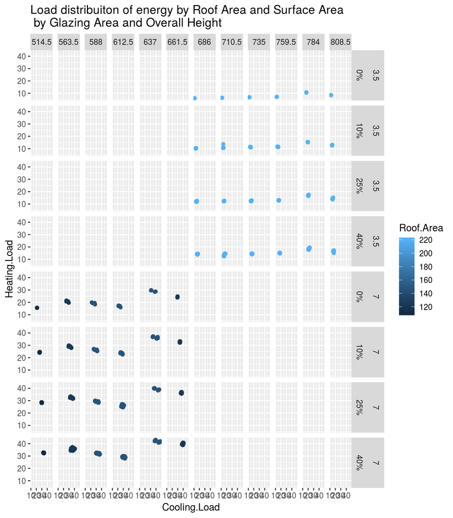

```r
## visualize if there is any relation between 'Roof.Area', 'Surface.Area' and 'Glazing.Area' and how load is distributed using scatter plot.
ggplot(df, aes(x = Cooling.Load, y = Heating.Load), alpha = 0.5)+
  geom_point(aes(colour = Roof.Area ))+
  facet_grid(Overall.Height + Glazing.Area ~ Surface.Area,  space = "free") +
  ggtitle("Load distribuiton of energy by Roof Area and Surface Area \n by Glazing Area and Overall Height")
```

Observations:

- Roof area and Surface area range is high for minimum/ lowest (3.5) over-all height and
- Roof area and Surface area range is low for maximum/ highest (7.0) over-all height.
- There are no data points when the overall height is 7 and highest surface area range and also for low overall height 3.5, we have no data points with the low surface area range.

## Plot Heating Load Efficiency

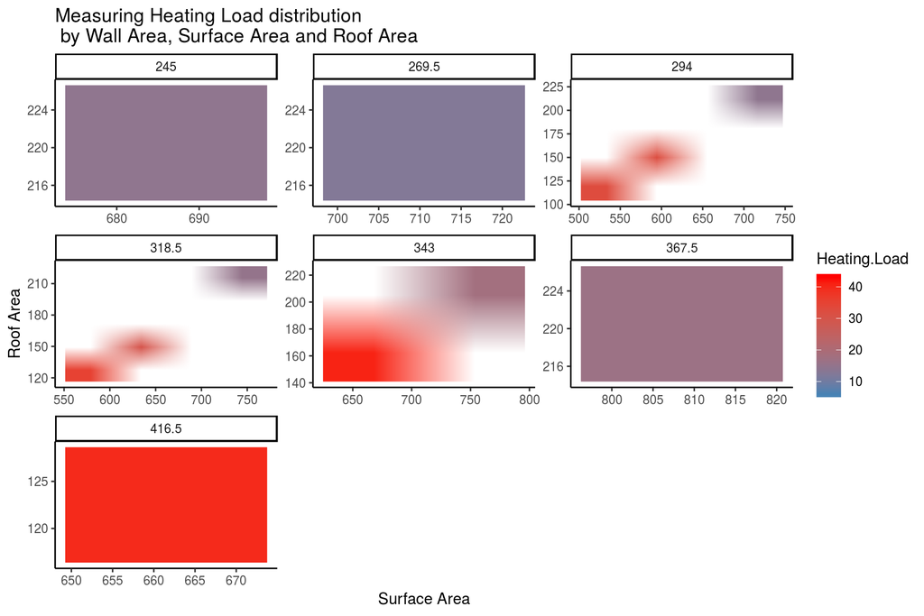

```r
## plot how 'Wall.Area' influence heating load using raster plot.
ggplot(df, aes( Surface.Area, Roof.Area)) +
  geom_raster(aes(fill = Heating.Load), interpolate = TRUE) +
  scale_fill_gradient(low = "steelblue", high = "red")+
  facet_wrap(~Wall.Area, scales = "free" )+
  ggtitle('Measuring Heating Load distribution \n by Wall Area, Surface Area and Roof Area') +
  xlab('Surface Area') + ylab('Roof Area') +
  theme_classic()
```

Observations:

## Plot Cooling Load Efficiency

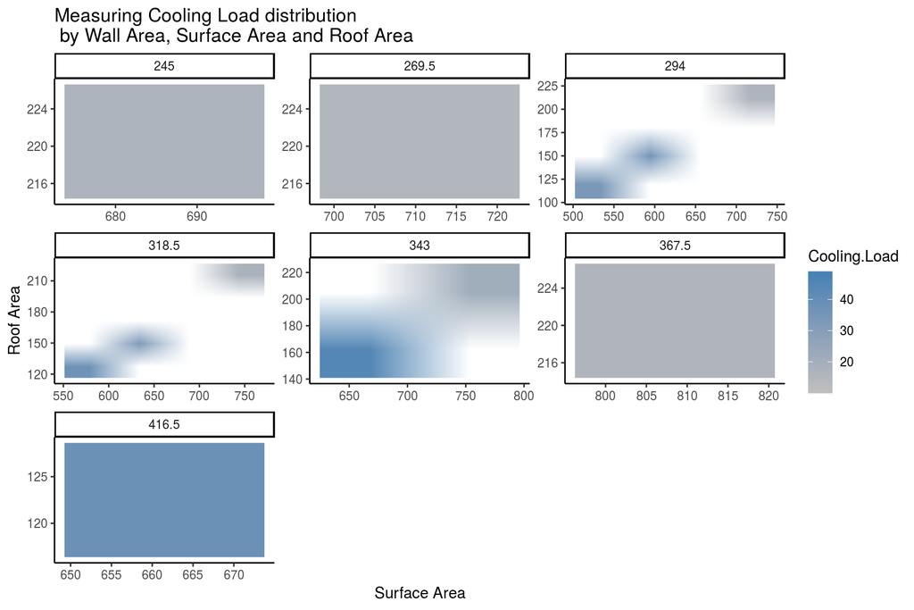

```r
## plot how 'Wall.Area' influence cooling load using raster plot.
ggplot(df, aes(Surface.Area, Roof.Area)) +
  geom_raster(aes(fill = Cooling.Load), interpolate = TRUE) +
  scale_fill_gradient(low = "grey", high = "steelblue")+
  facet_wrap(~Wall.Area, scales = "free" )+
  ggtitle('Measuring Cooling Load distribution \n by Wall Area, Surface Area and Roof Area') +
  xlab('Surface Area') + ylab('Roof Area') +
  theme_classic()
```

Observations:

- So, **Wall Area** plays a significant role in both Heating and Cooling Load efficiency.

## Plot Energy Efficiency

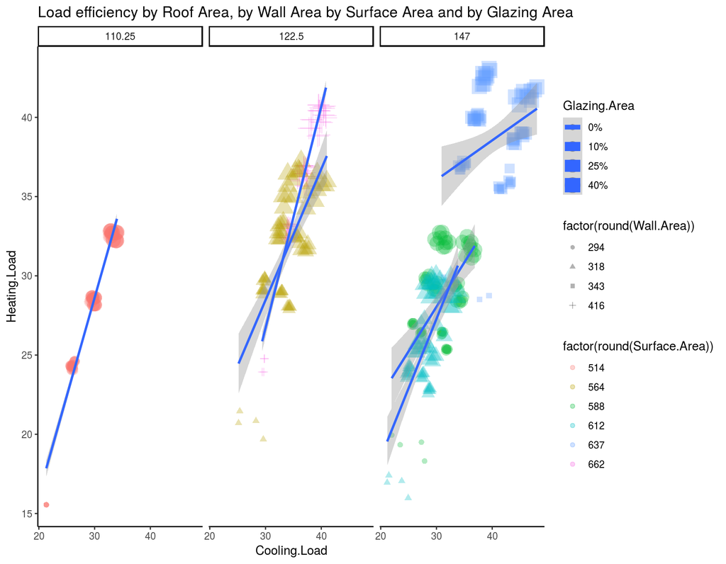

```r
## we have seen more variation in load data when the overall height is (7.0). So lets create a subset named(energy.eff.sub7.0) which contains the filtered data with overall height = 7.0. Lets visualize, if the 'Roof.Area', 'Wall.Area', 'Surface.Area' and 'Glazing.Area' are influencing the load efficiency.
energy.eff.sub7.0 <- df[ df$Overall.Height ==7.0,]
ggplot(energy.eff.sub7.0,
       aes(x = Cooling.Load, y = Heating.Load, group = factor(round(Wall.Area)),
           size = Glazing.Area,
           shape = factor(round(Wall.Area))))+
  geom_point(aes(colour= factor(round(Surface.Area))), alpha = 0.3)+
  geom_smooth(method = "lm",se = TRUE )+
  facet_wrap(~ Roof.Area) +
  ggtitle('Load efficiency by Roof Area, by Wall Area by Surface Area and by Glazing Area') +
  theme_classic()
```

Observations: